# L05 Annotation & Positioning

Data Visualization (STAT 302)

Author

Bud Green

## Overview

The goal of this lab is to explore methods for annotating and positioning with `ggplot2` plots. This lab also utilizes `scale_*` to a greater degree which is part of our next reading. In fact, students may find going through/reading chapter [11 Colour scales and legends](https://ggplot2-book.org/scale-colour.html) useful.

## Datasets

We’ll be using the `blue_jays.rda`, `titanic.rda`, `Aus_athletes.rda`, and `tech_stocks.rda` datasets.

## Exercises

Complete the following exercises.

## Exercise 1

Using the `blue_jays.rda` dataset, recreate the following graphic as precisely as possible.

*Hints:*

- Transparency is 0.8
- Point size 2
- Create a `label_info` dataset that is a subset of original data, just with the 2 birds to be labeled
- Shift label text horizontally by 0.5
- See ggplot2 textbook 8.3 building custom annotations
- Annotation size is 4
- Classic theme

**Solution**

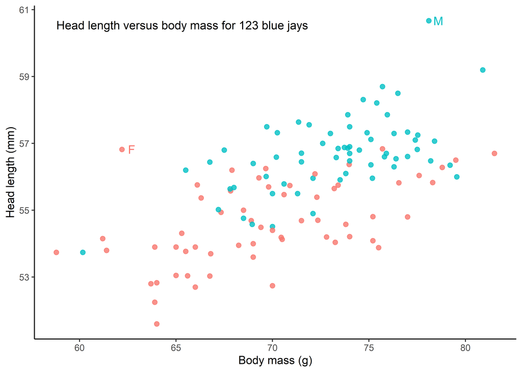

```r
#location info for annotation
y_range <- (range(blue_jays$Head))
x_range <- (range(blue_jays$Mass))
caption <- "Head length versus body mass for 123 blue jays"
# $ is access
#data for geom_text labels
bird_list <- c("1142-05914", "702-90567")

label_info <- blue_jays %>%
  filter(BirdID %in% c("1142-05914", "702-90567"))
#does not distribute the BirdID == part
#could also make the bird_list if I had a lot more things to label and call that instead of the c() in the filter


#build plot
blue_jays %>%
  ggplot(aes(Mass, Head, color = KnownSex)) +
  geom_point(
    size = 2,
    alpha = 0.8,
    show.legend = FALSE
  ) +
  geom_text(
    data = label_info,
    mapping = aes(label = KnownSex),
    nudge_x = 0.5,
    size = 4,
    show.legend = FALSE
  ) +
  theme_classic() +
  labs(
    x = "Body mass (g)",
    y = "Head length (mm)",
  ) +
  annotate(
    geom = "text",
    x = x_range[1],
    y = y_range[2],
    label = caption,
    hjust = 0,
    vjust = 1,
    size = 4
  )
```

```r
#annotate is putting a box at the first value in x_range, second value for y_range
#the point given for x, y is the center of the box
#hjust, vjust moves the starting point of the box (range from 0-1 and default is 0.5, 0.5)
```

## Exercise 2

Using the `tech_stocks` dataset, recreate the following graphics as precisely as possible. Use the column `price_indexed`.

### Plot 1

*Hints:*

- Create a `label_info` dataset that is a subset of original data, just containing the last day’s information for each of the 4 stocks
- serif font
- Annotation size is 4

**Solution**

```r
x_range <- (range(tech_stocks$date))
y_range <- (range(tech_stocks$price_indexed))
caption <- "Stock price over time for four major tech companies"

label_info <- tech_stocks %>%
  group_by(company) %>%
  filter(date == max(date)) %>%
  ungroup()

tech_stocks %>%
  slice_max(date, by = company)
```

```
# A tibble: 4 × 6
  company   ticker date       price index_price price_indexed
  <chr>     <chr>  <date>     <dbl>       <dbl>         <dbl>
1 Alphabet  GOOG   2017-06-02 976.        285.           342.
2 Apple     AAPL   2017-06-02 155.         80.1          194.
3 Facebook  FB     2017-06-02 154.         27.7          554.
4 Microsoft MSFT   2017-06-02  71.8        28.4          252.
```

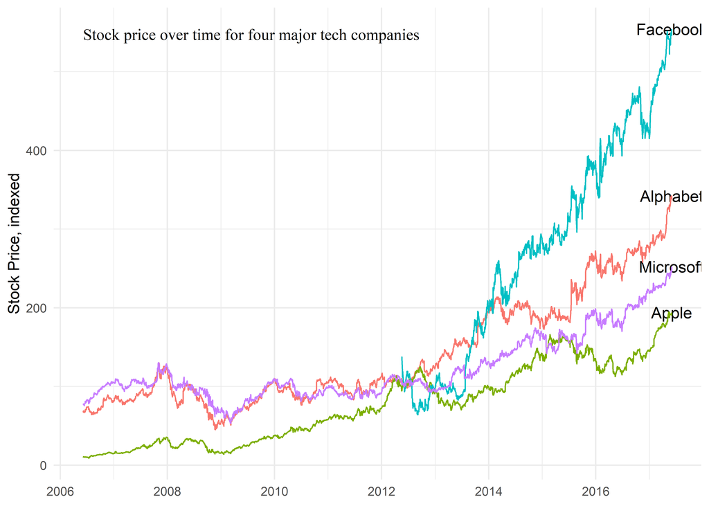

```r
tech_stocks %>%
  ggplot(
    aes(date, price_indexed)
    ) +
    geom_text(
      data = label_info,
      mapping = aes(label = company),
      size = 4,
      show.legend = FALSE
      ) +
    geom_line(
      mapping = aes(color = company),
      show.legend = FALSE
      ) +
    labs(
      y = "Stock Price, indexed",
      x = NULL
      ) +
    annotate(
      geom = "text",
      x = x_range[1],
      y = y_range[2],
      label = caption,
      hjust = 0,
      vjust = 1,
      size = 4,
      family = "serif"
      ) +
    theme_minimal()
```

```r
#Using "" removes the label but takes up the space. Using "NULL" does not take up space
```

### Plot 2

*Hints:*

- Package `ggrepel`
  - `box.padding` is 0.6
  - Minimum segment length is 0
  - Horizontal justification is to the right
  - seed of 9876
- Annotation size is 4
- serif font

**Solution**

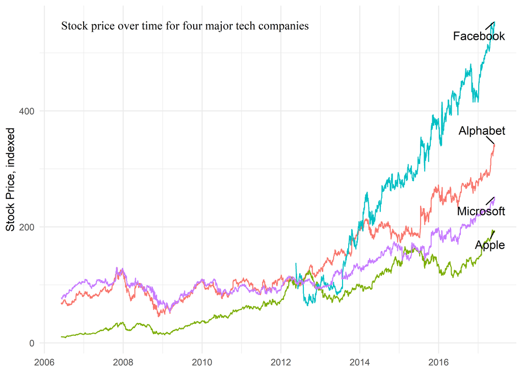

```r
ggplot(data = tech_stocks, aes(date, price_indexed)) +
  geom_line(
      mapping = aes(color = company),
      show.legend = FALSE
      ) +
  geom_text_repel(
    data = label_info,
    mapping = aes(label = company),
    size = 4,
    show.legend = FALSE,
    box.padding = 0.6,
    hjust = 1,
    seed = 9876,
    min.segment.length = 0
    ) +
    labs(
      y = "Stock Price, indexed",
      x = NULL
      ) +
    annotate(
      geom = "text",
      x = x_range[1],
      y = y_range[2],
      label = caption,
      hjust = 0,
      vjust = 1,
      size = 4,
      family = "serif",
      ) +
    theme_minimal()
```

## Exercise 3

Using the `titanic.rda` dataset, recreate the following graphic as precisely as possible.

*Hints:*

- Create a new variable that uses `died` and `survived` as levels/categories
- Hex colors: `#D55E00D0`, `#0072B2D0` (no alpha is being used)

**Solution**

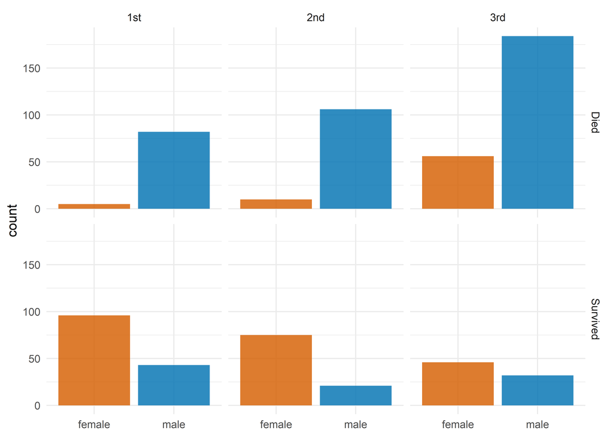

```r
sex_colors <- c(female = "#D55E00D0", male = "#0072B2D0")
ggplot(titanic, aes(sex, fill = sex)) +
  geom_bar(show.legend = FALSE) +
  facet_grid(survived ~ class) +
  theme_minimal() +
  labs(x = NULL) +
  scale_fill_manual(values = sex_colors)
```

## Exercise 4

Use the `athletes_dat` dataset — extracted from `Aus_althetes.rda` — to recreate the following graphic as precisely as possible. **Create the graphic twice**: once using `patchwork` and once using `cowplot`.

```r
# Get list of sports played by BOTH sexes
both_sports <- Aus_athletes |>
  # dataset of columns sex and sport
  # only unique observations
  distinct(sex, sport) |>
  # see if sport is played by one gender or both
  count(sport) |>
  # only want sports played by BOTH sexes
  filter(n == 2) |>
  # get list of sports
  pull(sport)

# Process data
athletes_dat <- Aus_athletes |>
  # only keep sports played by BOTH sexes
  filter(sport %in% both_sports) |>
  # rename track (400m) and track (sprint) to be track
  # case_when will be very useful with shiny apps
  mutate(
    sport = case_when(
      sport == "track (400m)" ~ "track",
      sport == "track (sprint)" ~ "track",
      TRUE ~ sport
      )
    )
```

*Hints:*

- Build each plot separately
- Bar plot: lower limit 0, upper limit 95
- Bar plot: shift bar labels by 5 units and top justify
- Bar plot: label size is 5
- Bar plot: `#D55E00D0` & `#0072B2D0` — no `alpha`
- Scatterplot: `#D55E00D0` & `#0072B2D0` — no `alpha`
- Scatterplot: filled circle with “white” outline; size is 3
- Scatterplot: `rcc` is red blood cell count; `wcc` is white blood cell count
- Boxplot: outline `#D55E00` and `#0072B2`; shading `#D55E0040` and `#0072B240`
- Boxplot: should be made narrower; 0.5
- Boxplot: Legend is in top-right corner of bottom plot
- Boxplot: Space out labels `c("female ", "male")`
- Boxplot: Legend shading matches hex values for top two plots

### Using `patchwork`

**Solution**

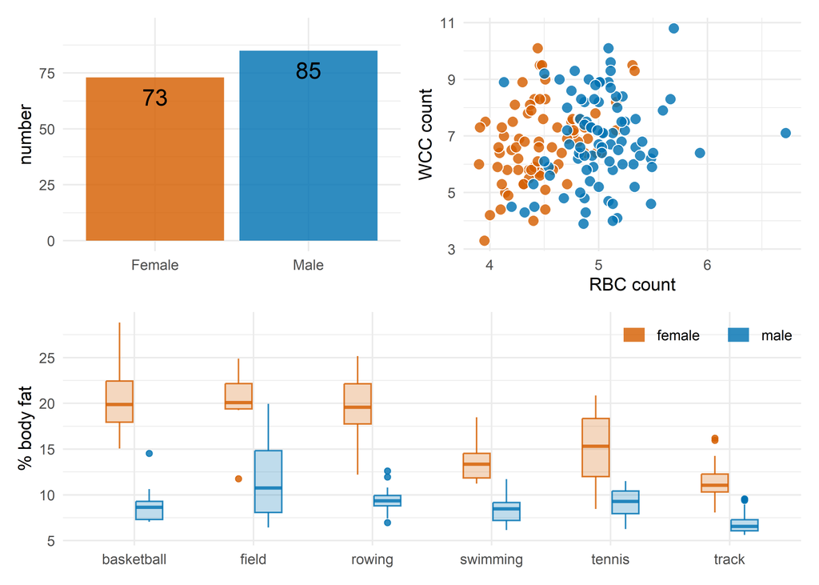

```r
aus_sex_colors <- c(f = "#D55E00D0", m = "#0072B2D0")
aus_sex_colors_shading <- c(f = "#D55E0040", m = "#0072B240")

aus_bar_plot <- ggplot(athletes_dat, aes(sex, fill = sex)) +
  geom_bar(show.legend = FALSE) +
  scale_fill_manual(values = aus_sex_colors) +
  ylim(0, 95) +
  theme_minimal() +
  labs(x = NULL, y = "number") +
  geom_text(aes(label = after_stat(count)), stat = "count", vjust = 1, size = 5, position = position_nudge(y = -5)) +
  scale_x_discrete(labels = c("f" = "Female", "m" = "Male"))

aus_dot_plot <- ggplot(athletes_dat, aes(rcc, wcc, fill = sex)) +
  geom_point(show.legend = FALSE, shape = 21, size = 3, color = "white") +
  scale_fill_manual(values = aus_sex_colors, guide = "none") +
  labs(x = "RBC count", y = "WCC count") +
  theme_minimal()

aus_box_plot <- ggplot(athletes_dat, aes(sport, pcBfat, fill = sex, color = sex)) +
  geom_boxplot(width = 0.5) +
  scale_fill_manual(name = NULL, values = aus_sex_colors_shading, labels = c("female    ", "male")) +
  scale_color_manual(name = NULL, values = aus_sex_colors, labels = c("female    ", "male")) +
  theme_minimal() +
  theme(
    legend.justification = c(1,1),
    legend.position = "inside",
    legend.position.inside = c(1,1),
    legend.direction = "horizontal"
  ) +
  guides(
    fill = guide_legend(
      override.aes = list(
        color = NA,
        fill = aus_sex_colors
        )
      )
    ) +
  labs(x = NULL, y = "% body fat")

(aus_bar_plot + aus_dot_plot) / aus_box_plot
```

### Using `cowplot`

Use [`cowplot::plot_grid()`](https://wilkelab.org/cowplot/articles/plot_grid.html) to combine them.

**Solution**

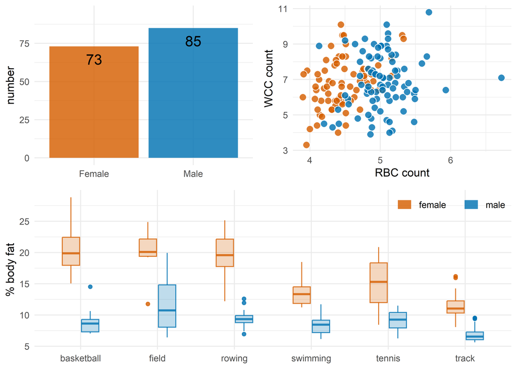

```r
top_row <- plot_grid(aus_bar_plot, aus_dot_plot, nrow = 1)
plot_grid(top_row, aus_box_plot, ncol = 1)
```

```r
#June said I needed to use align = "h" but that didn't work for me so I used the ponopto video
```

## Exercise 5

Create the following graphic using `patchwork`.

*Hints:*

- Use plots created in Exercise 4
- inset theme is classic
  - Useful values: 0, 0.45, 0.75, 1
- plot annotation `"A"`

**Solution**

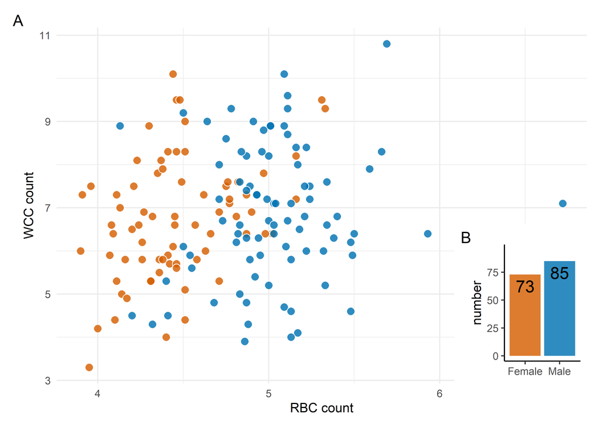

```r
aus_dot_plot +
  inset_element(
    aus_bar_plot + theme_classic(),
    left = 0.75,
    bottom = 0,
    right = 1,
    top = 0.45
  ) +
  plot_annotation(tag_levels = "A")
```